# Data 624 - Homework #5

Paul Britton

2020-03-08

Exercises 8.1, 8.2, 8.3, 8.5, 8.6 and 8.7 from the Hyndman online Forecasting book. The rpubs version of this work can be found here, and source/data can be found on github here.

```r
#clear the workspace
rm(list = ls())

#load req's packages
library(fpp2)
library(knitr)
library(tseries)
library(knitr)
```

## Question 8.1

Figure 8.31 shows the ACFs for 36 random numbers, 360 random numbers and 1,000 random numbers.

### A) Explain the differences among these figures. Do they all indicate that the data are white noise?

The figures indicate that the data is white noise given that there are no observations outside of the critical values. The main difference appears to be the width of the limits which is driven by the sample size.

### B) Why are the critical values at different distances from the mean of zero? Why are the autocorrelations different in each figure when they each refer to white noise?

As mentioned in the response to part A, as the sample size grows, confidence is higher and thus the critical values decrease. The relationship is: $\pm1.96/\sqrt{N}$, which makes it pretty clear that as N grows, the critical value will decrease.

## Question 8.2

A classic example of a non-stationary series is the daily closing IBM stock price series (data set ibmclose). Use R to plot the daily closing prices for IBM stock and the ACF and PACF. Explain how each plot shows that the series is non-stationary and should be differenced.

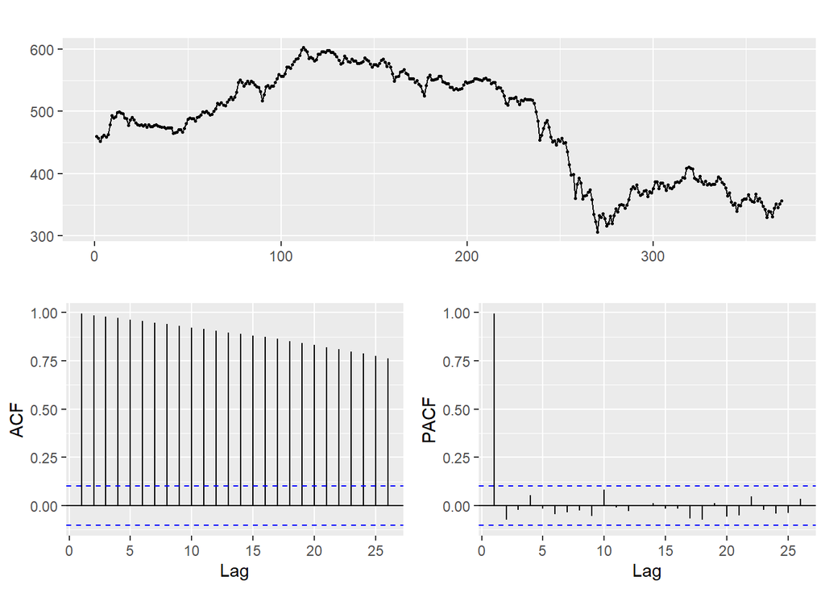

```r
data(ibmclose)
ggtsdisplay(ibmclose)
```

[figure not shown]

```r
ibmclose.diff <- diff(ibmclose)
ggtsdisplay(ibmclose.diff)
```

#### Timeseries

The timeseries itself doesn’t look stationary. It appears to have a piece-wise drifting behaviour, non-constant variability, and it doesn’t appear to osscilate around a central value as we might expect from a stationary series. Essentially right now, the series is a cumsum() of daily price changes - we want to see the series of changes, which will oscillate around zero and appear much more stationary.  
#### ACF The ACF series shows that at all lags presented, the observed correlation is well above the critical values. This suggests that the samples are not independent and differencing may help break this relationship. #### PCAF The PACF shows that the relationship between the series and that, specifically for a 1-period lag, the relationship appears to be extremely high. Similarl to the ACF, this suggests that there is information in the lagged series and thus it is not independent.

#### Let’s look at the diff

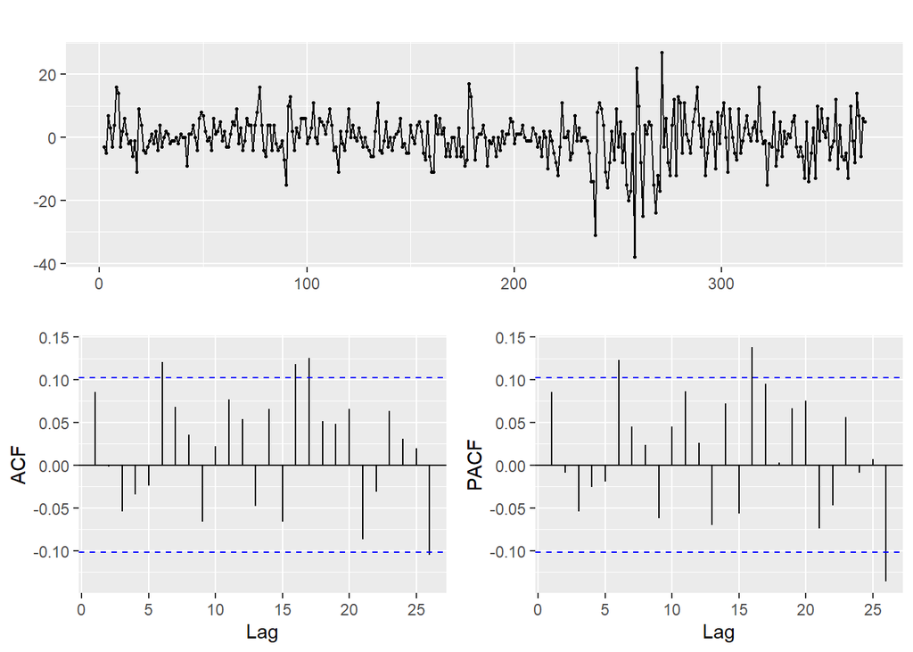

```r
ibmclose.diff <- diff(ibmclose)
ggtsdisplay(ibmclose.diff)
```

We can see that if we DO difference the data, we get much better resutls. The data, however, while much closer to stationarity, is not perfect. This is likely as a result of time-varying variance of the series (between 0-100 and 200-300 look very different, for example)

## Question 8.3

For the following series, find an appropriate Box-Cox transformation and order of differencing in order to obtain stationary data.

### A) usnetelec

The data appears to be relatively steadily increasing.

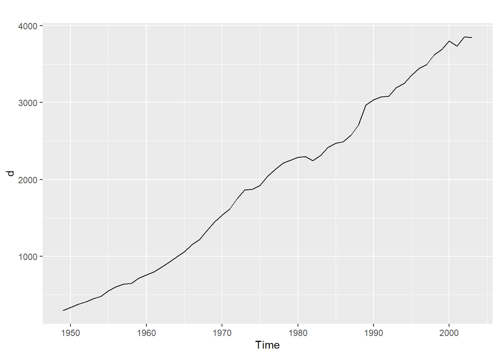

```r
d <- usnetelec
autoplot(d)
```

```r
lambda <-  BoxCox.lambda(d)
d <- BoxCox(d,lambda)
```

```r
order <- 2

Box.test(diff(d,differences=order), type = "Ljung-Box")
```

```
##
##  Box-Ljung test
##
## data:  diff(d, differences = order)
## X-squared = 8.3324, df = 1, p-value = 0.003895
```

```r
kpss.test(diff(d,differences=order))
```

```
##
##  KPSS Test for Level Stationarity
##
## data:  diff(d, differences = order)
## KPSS Level = 0.071991, Truncation lag parameter = 3, p-value = 0.1
```

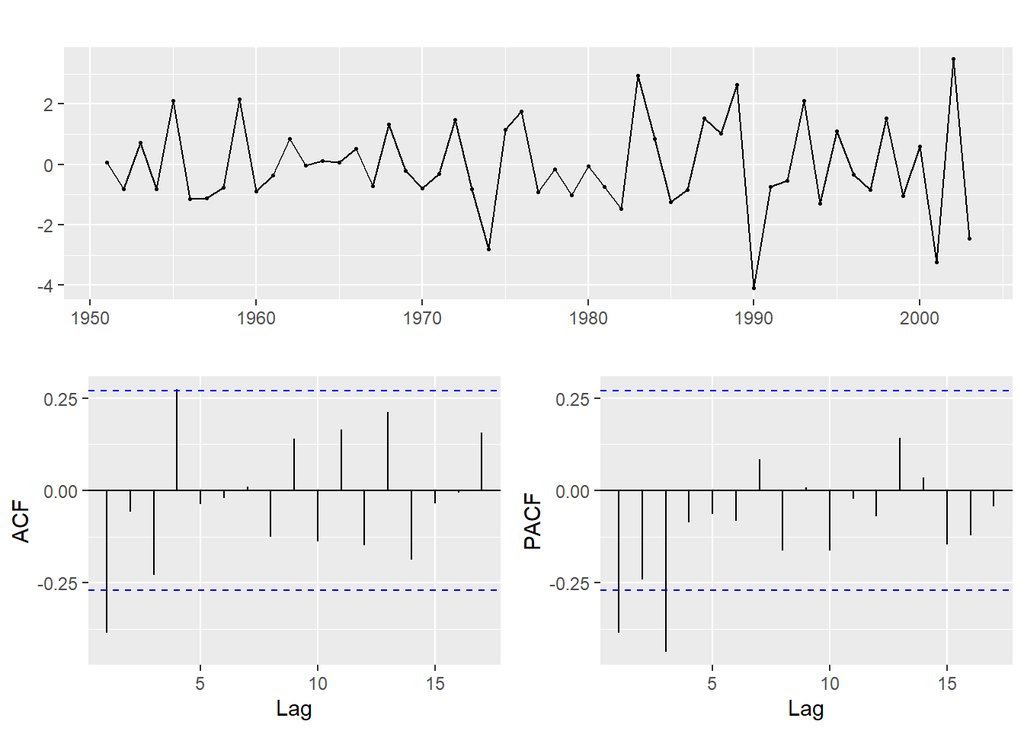

```r
ggtsdisplay(diff(d,differences=order))
```

For this data, an appropriate lambda would be 0.52 and 2nd order differencing appears appropriate.

### B) usgdp

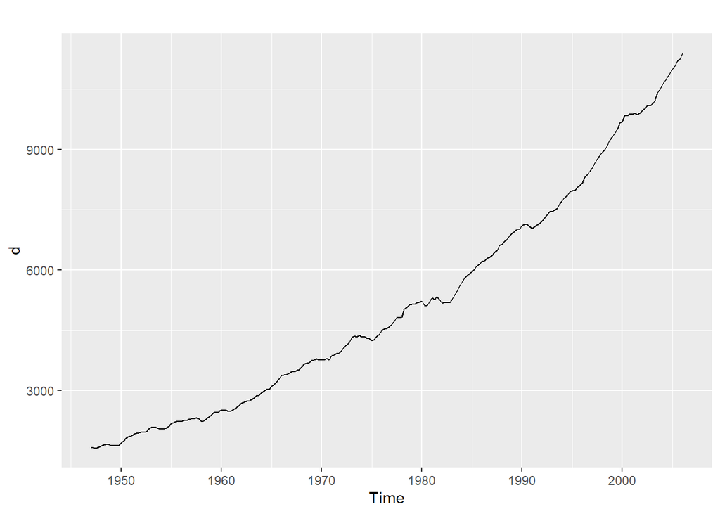

```r
d <- usgdp
autoplot(d)
```

```r
lambda <-  BoxCox.lambda(d)
d <- BoxCox(d,lambda)
```

```r
order <- 2

Box.test(diff(d,differences=order), type = "Ljung-Box")
```

```
##
##  Box-Ljung test
##
## data:  diff(d, differences = order)
## X-squared = 41.715, df = 1, p-value = 1.056e-10
```

```r
kpss.test(diff(d,differences=order))
```

```
##
##  KPSS Test for Level Stationarity
##
## data:  diff(d, differences = order)
## KPSS Level = 0.011953, Truncation lag parameter = 4, p-value = 0.1
```

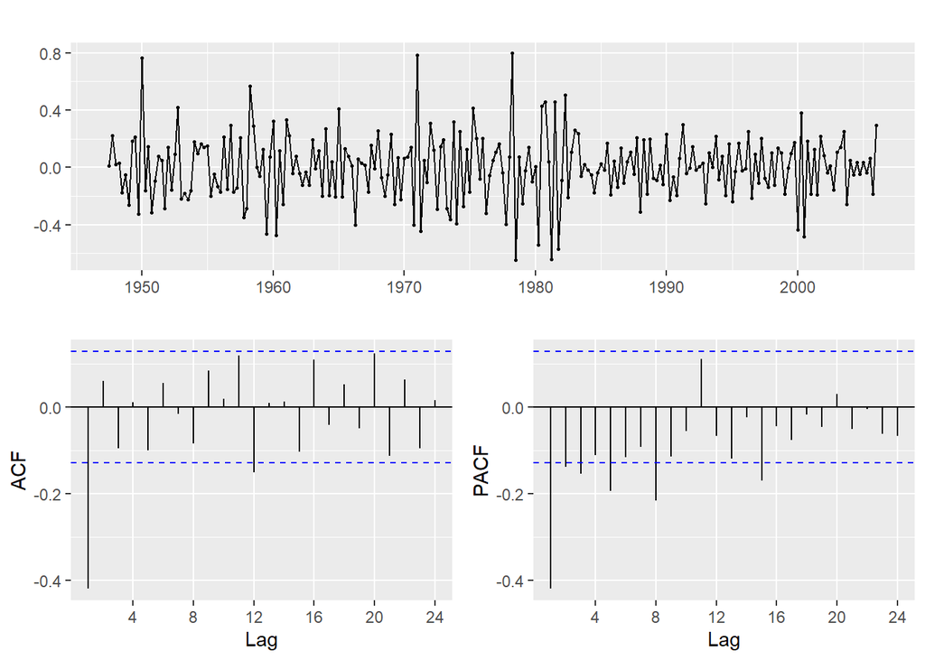

```r
ggtsdisplay(diff(d,differences=order))
```

```r
order <- 2

Box.test(diff(d,differences=order), type = "Ljung-Box")
```

```
##
##  Box-Ljung test
##
## data:  diff(d, differences = order)
## X-squared = 41.715, df = 1, p-value = 1.056e-10
```

```r
kpss.test(diff(d,differences=order))
```

```
##
##  KPSS Test for Level Stationarity
##
## data:  diff(d, differences = order)
## KPSS Level = 0.011953, Truncation lag parameter = 4, p-value = 0.1
```

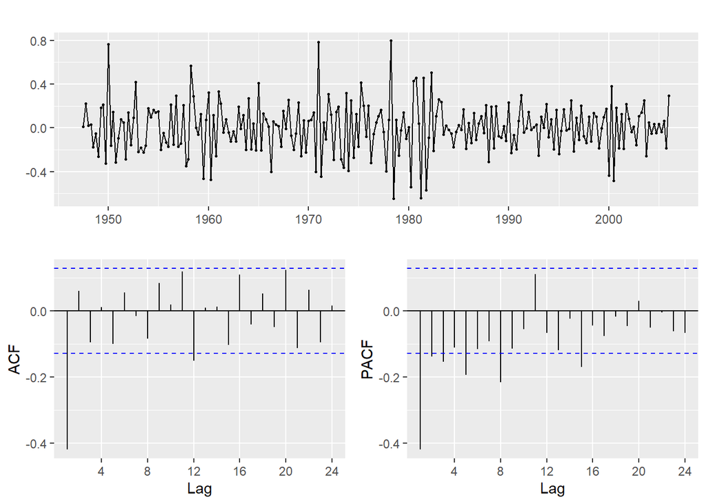

```r
ggtsdisplay(diff(d,differences=order))
```

2nd order differencing causes a pass of the KPSS test. There still appears to be some issues with auto-correlation but overall the results are likely. An appropriate lambda for box-cox is ~0.36

### C) mcopper

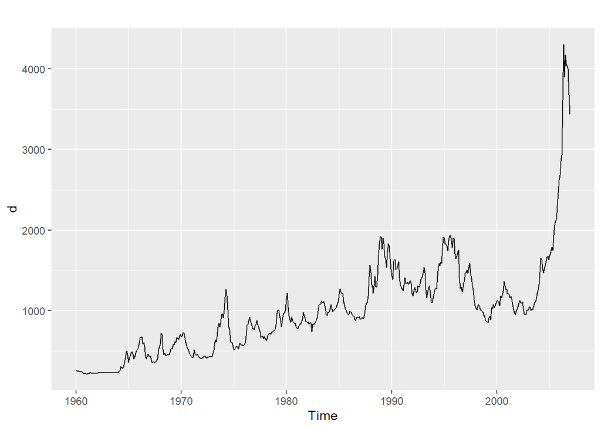

```r
d <- mcopper
autoplot(d)
```

```r
lambda <-  BoxCox.lambda(d)
d <- BoxCox(d,lambda)
```

```r
order <- 1
Box.test(diff(d,differences=order), type = "Ljung-Box")
```

```
##
##  Box-Ljung test
##
## data:  diff(d, differences = order)
## X-squared = 57.517, df = 1, p-value = 3.353e-14
```

```r
kpss.test(diff(d,differences=order))
```

```
##
##  KPSS Test for Level Stationarity
##
## data:  diff(d, differences = order)
## KPSS Level = 0.057275, Truncation lag parameter = 6, p-value = 0.1
```

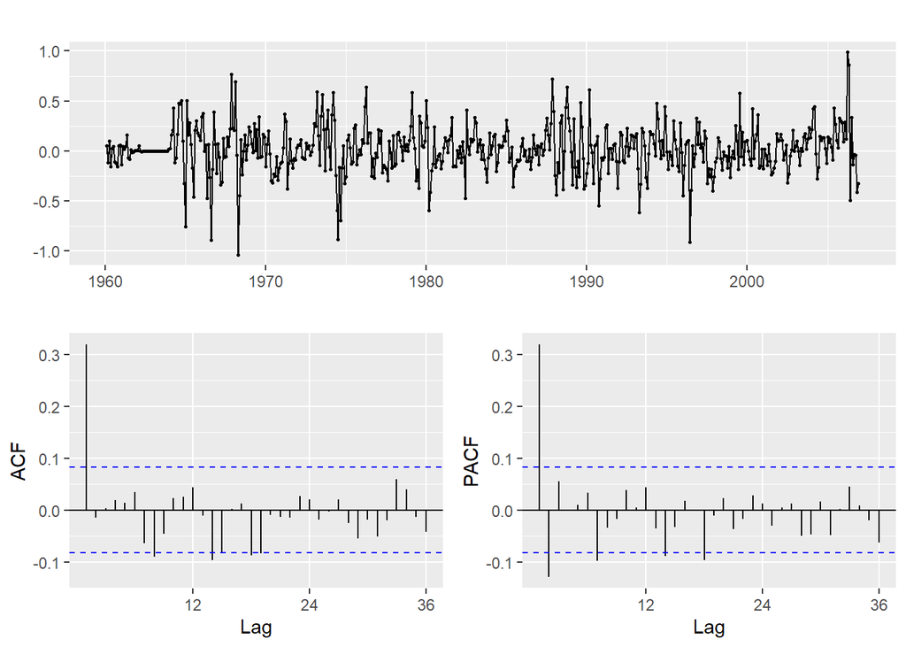

```r
ggtsdisplay(diff(d,differences=order))
```

First order differencing with a lambda of ~0.2 seems reasonably okay and probably acceptable. I wonder if the high ACF and PACF at lag 1 have something to do with the zero-change data in the 60s… a quick test:

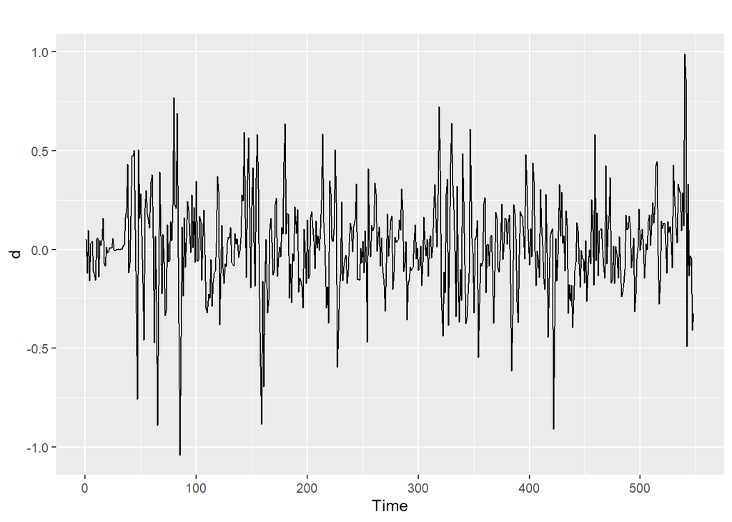

```r
d <- diff(d)
d <- ts(d[d != 0])
autoplot(d)
```

```r
lambda <-  BoxCox.lambda(d)
d <- BoxCox(d,lambda)



order <- 1
Box.test(d, type = "Ljung-Box")
```

```
##
##  Box-Ljung test
##
## data:  d
## X-squared = 56.73, df = 1, p-value = 4.996e-14
```

```r
kpss.test(d)
```

```
##
##  KPSS Test for Level Stationarity
##
## data:  d
## KPSS Level = 0.056935, Truncation lag parameter = 6, p-value = 0.1
```

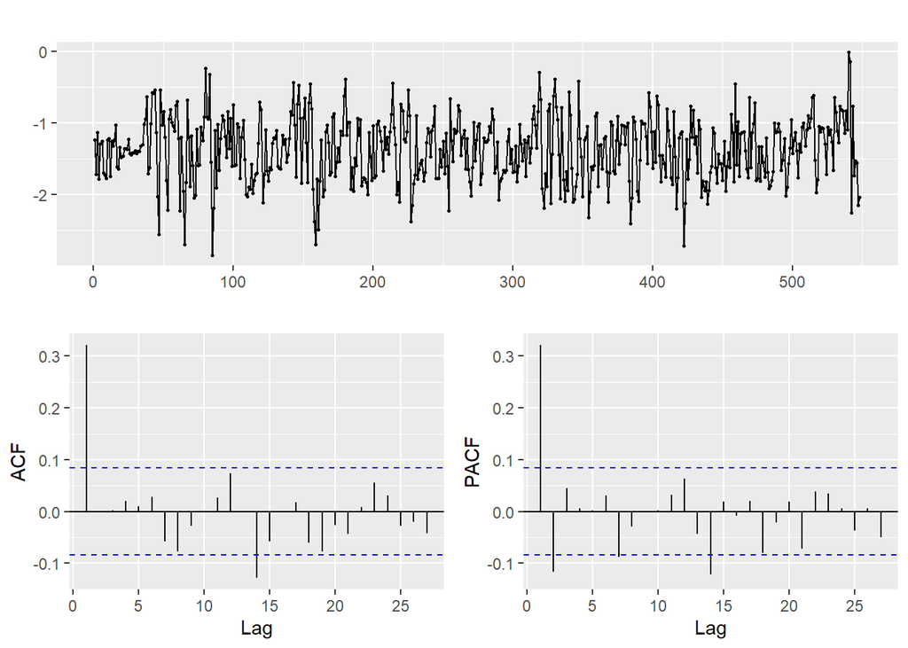

```r
ggtsdisplay(d)
```

We see a negligible change if we remove the zero entries. As such, a first order difference with a lambda of 0.71 seem appropriate.

### D) enplanements

These data are clearly showing a seasonal pattern so we will need to adjust for that.

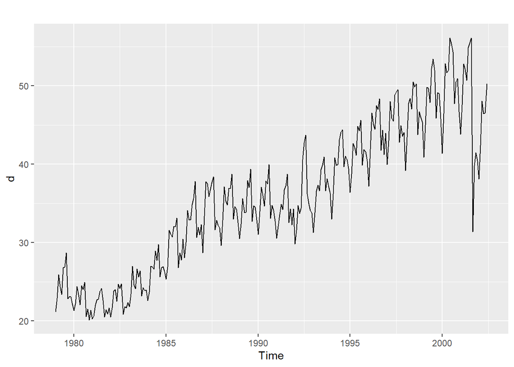

```r
d <- enplanements
autoplot(d)
```

```r
lambda <-  BoxCox.lambda(d)
d <- BoxCox(d,lambda)
```

```r
order <- 1
lag <- 12

Box.test(diff(diff(d,differences=order),lag=lag), type = "Ljung-Box")
```

```
##
##  Box-Ljung test
##
## data:  diff(diff(d, differences = order), lag = lag)
## X-squared = 29.562, df = 1, p-value = 5.417e-08
```

```r
kpss.test(diff(diff(d,differences=order),lag=lag))
```

```
##
##  KPSS Test for Level Stationarity
##
## data:  diff(diff(d, differences = order), lag = lag)
## KPSS Level = 0.042424, Truncation lag parameter = 5, p-value = 0.1
```

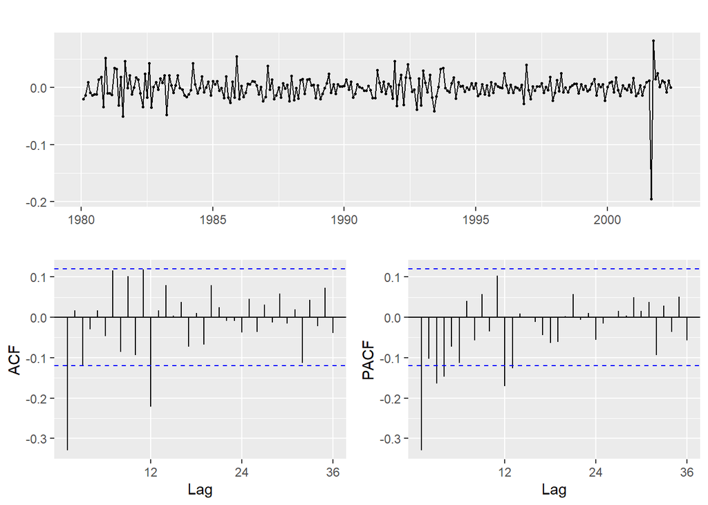

```r
ggtsdisplay(diff(diff(d,differences=order),lag=lag))
```

We can see that the appropriate value for lambda is ~-0.23. First order differencing was required as well as a 12-period lagged differencing to account for annual seasonality. Doing this, we get an acceptable KPSS result.

### E) visitors

This data appears to be similar to that of the last problem as as such, we’ll try the exact same technique (1st order diff, 12-period diff)

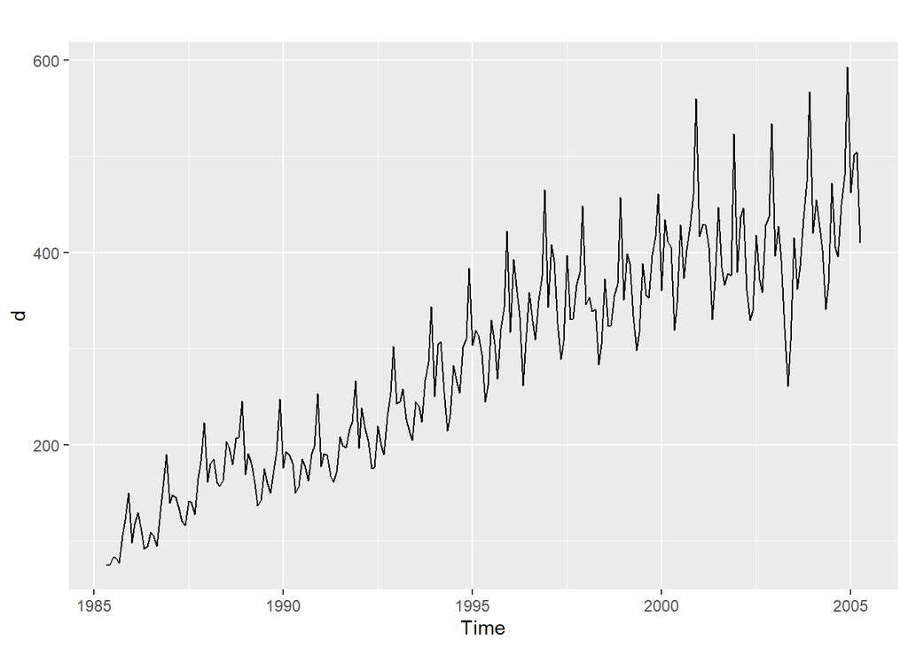

```r
d <- visitors
autoplot(d)
```

```r
lambda <-  BoxCox.lambda(d)
d <- BoxCox(d,lambda)
```

```r
order <- 1
lag <- 12

Box.test(diff(diff(d,differences=order),lag=lag), type = "Ljung-Box")
```

```
##
##  Box-Ljung test
##
## data:  diff(diff(d, differences = order), lag = lag)
## X-squared = 21.804, df = 1, p-value = 3.02e-06
```

```r
kpss.test(diff(diff(d,differences=order),lag=lag))
```

```
##
##  KPSS Test for Level Stationarity
##
## data:  diff(diff(d, differences = order), lag = lag)
## KPSS Level = 0.015833, Truncation lag parameter = 4, p-value = 0.1
```

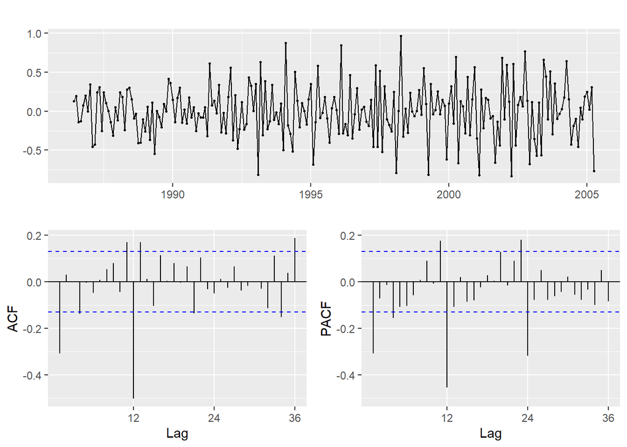

```r
ggtsdisplay(diff(diff(d,differences=order),lag=lag))
```

With a lambda of o.28 and using a first order diff and a 12-period correction for seasonality, we get a result that looks acceptably stationary.